# Лабораторная работа № 5

Дискреционное разграничение прав в Linux. Исследование влияния дополнительных атрибутов

Мальянц Виктория Кареновна

1132246740@rudn.ru

Российский университет дружбы народов

2026-04-03

# Цель работы

- Изучение механизмов изменения идентификаторов, применения SetUID- и Sticky-битов. Получение практических навыков работы в консоли с дополнительными атрибутами. Рассмотрение работы механизма смены идентификатора процессов пользователей, а также влияние бита Sticky на запись и удаление файлов.

# Задание

- Подготовка лабораторного стенда
- Создание программы
- Исследование Sticky-бита

# Выполнение лабораторной работы

## Подготовка лабораторного стенда

- Убеждаюсь, что в системе установлен компилятор gcc с помощью команды gcc -v (рис. 1).

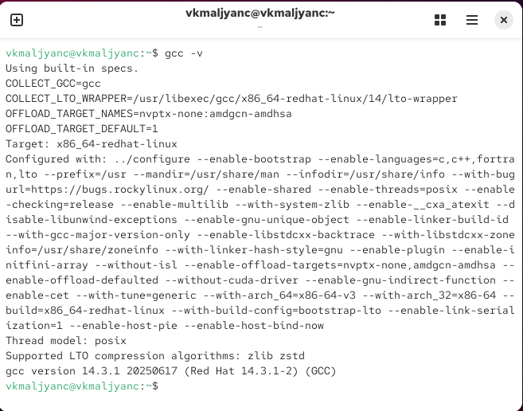

Применение команды gcc -v

## Подготовка лабораторного стенда

- Отключаю систему запретов до очередной перезагрузки системы командой sudo setenforce 0. После этого команда getenforce выводит Permissive (рис. 2).

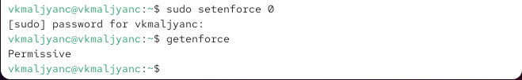

Применение команд sudo setenforce 0 и getenforce

## Создание программы

- Вхожу в систему от имени пользователя guest с помощью команды sudo -u guest -i (рис. 3).

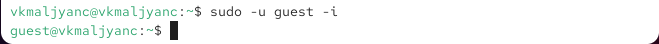

Применение команды sudo -u guest -i

## Создание программы

- Код программы simpleid.c (рис. 5).

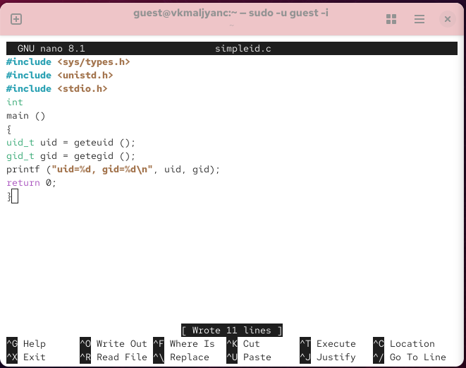

Код программы simpleid.c

## Создание программы

- Компилирую программу и убеждаюсь, что файл программы создан: gcc simpleid.c -o simpleid (рис. 6).

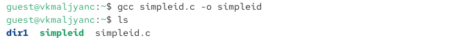

Применение команды gcc simpleid.c -o simpleid

## Создание программы

- Код программы simpleid2.c (рис. 9).

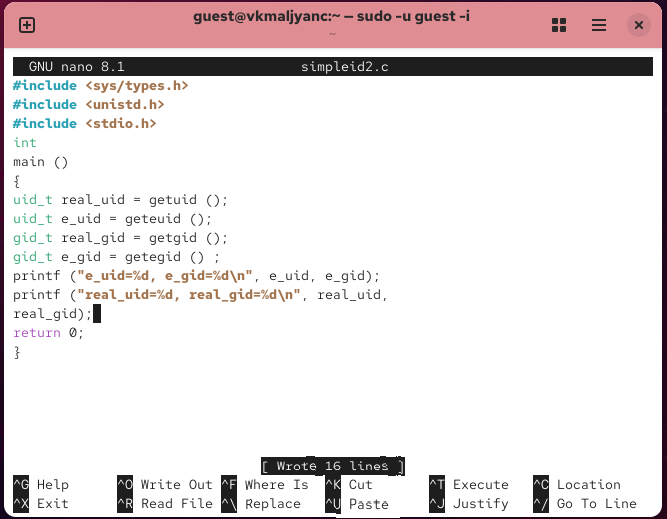

Код программы simpleid2.c

## Создание программы

- Компилирую и запускаю simpleid2.c. Применение команды gcc simpleid2.c -o simpleid2 и ./simpleid2 (рис. 10).

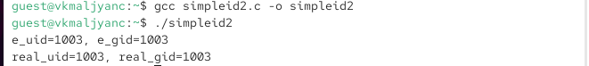

Применение команд gcc simpleid2.c -o simpleid2 и ./simpleid2

## Создание программы

- От имени суперпользователя выполняю команды: chown root:guest /home/guest/simpleid2 и chmod u+s /home/guest/simpleid2 (рис. 11).

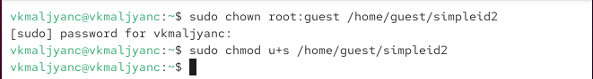

Применение команд sudo chown root:guest /home/guest/simpleid2 и sudo chmod u+s /home/guest/simpleid2

## Создание программы

- Выполняю проверку правильности установки новых атрибутов и смены владельца файла simpleid2: ls -l simpleid2 (рис. 12).

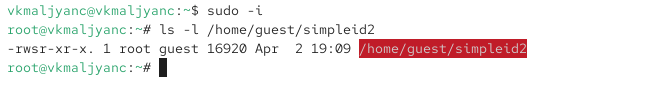

Применение команды ls -l simpleid2

## Создание программы

- Запускаю simpleid2 и id: ./simpleid2 и id. Вывод команды id более подробный (рис. 13).

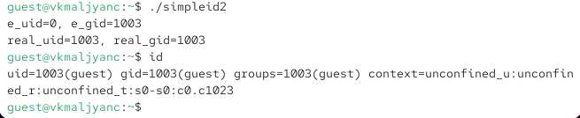

Применение команд ./simpleid2 и id

## Создание программы

- Код программы readfile.c (рис. 15).

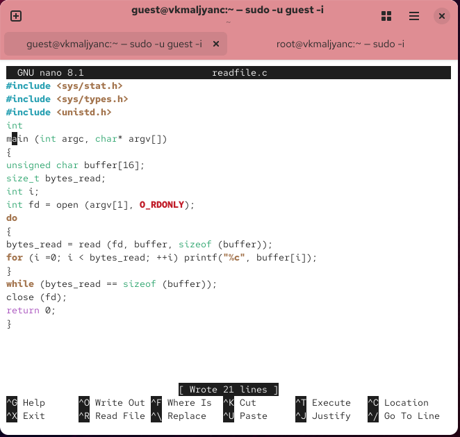

Код программы readfile.c

## Создание программы

- Меняю владельца у файла readfile.c и изменяю права так, чтобы только суперпользователь (root) мог прочитать его, a guest не мог (рис. 17).

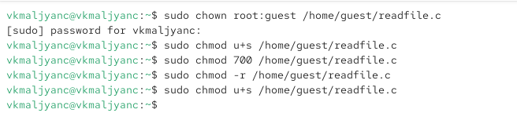

Изменение прав

## Создание программы

- Меняю у программы readfile владельца и устанавливаю SetU’D-бит. Проверяю, может ли программа readfile прочитать файл readfile.c (рис. 19).

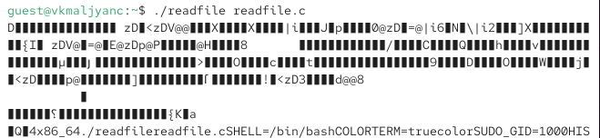

Проверка чтения файла readfile.c

## Создание программы

- Проверяю, может ли программа readfile прочитать файл /etc/shadow (рис. 20).

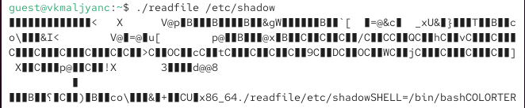

Проверка чтения файла /etc/shadow

## Создание программы

- Проверяю, может ли программа readfile прочитать файл /etc/shadow от суперпользователя (рис. 21).

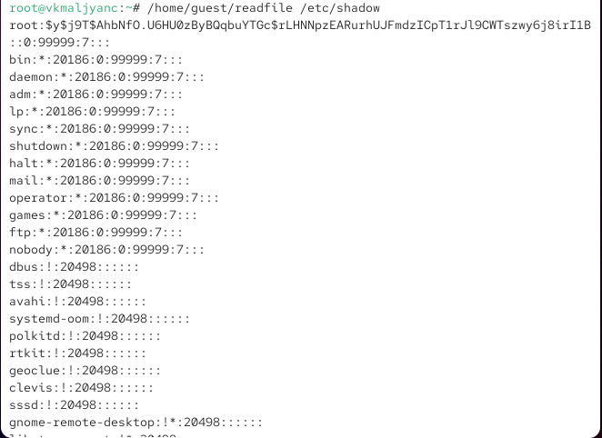

Проверка чтения файла /etc/shadow от суперпользователя

## Исследование Sticky-бита

- Просматриваю атрибуты у только что созданного файла и разрешаю чтение и запись для категории пользователей «все остальные»: ls -l /tmp/file01.txt chmod o+rw /tmp/file01.txt ls -l /tmp/file01.txt (рис. 24).

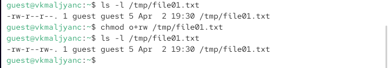

Применение команд ls -l /tmp/file01.txt, chmod o+rw /tmp/file01.txt, ls -l /tmp/file01.txt

## Исследование Sticky-бита

- От пользователя guest2 (не являющегося владельцем) пробую прочитать файл /tmp/file01.txt: cat /tmp/file01.txt (рис. 25).

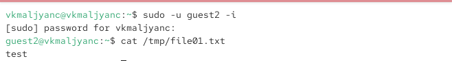

Применение команды cat /tmp/file01.txt

## Исследование Sticky-бита

- От пользователя guest2 пробую дозаписать в файл /tmp/file01.txt слово test2 командой echo “test2” > /tmp/file01.txt. Не удалось выполнить операцию (рис. 26).

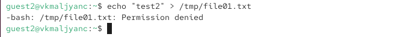

Применение команды echo “test2” > /tmp/file01.txt

## Исследование Sticky-бита

- Проверяю содержимое файла командой cat /tmp/file01.txt (рис. 27).

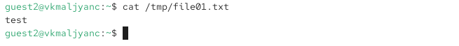

Применение команды cat /tmp/file01.txt

## Исследование Sticky-бита

- От пользователя guest2 пробую записать в файл /tmp/file01.txt слово test3, стерев при этом всю имеющуюся в файле информацию командой echo “test3” > /tmp/file01.txt. Не удалось выполнить операцию (рис. 28).

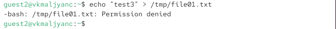

Применение команды echo “test3” > /tmp/file01.txt

## Исследование Sticky-бита

- От пользователя guest2 пробую удалить файл /tmp/file01.txt командой rm /tmp/fileOl.txt Не удалось удалить файл (рис. 30).

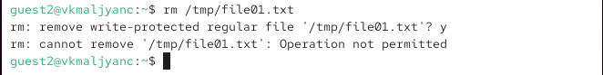

Применение команды rm /tmp/fileOl.txt

## Исследование Sticky-бита

- Повышаю свои права до суперпользователя следующей командой su - и выполняю после этого команду, снимающую атрибут t (Sticky-бит) с директории /tmp: chmod -t /tmp (рис. 31).

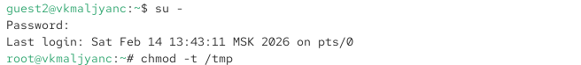

Применение команды chmod -t /tmp

## Исследование Sticky-бита

- Покидаю режим суперпользователя командой exit (рис. 32).

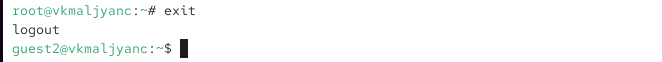

Применение команды exit

## Исследование Sticky-бита

- От пользователя guest2 проверяю, что атрибута t у директории /tmp нет: ls -l / | grep tmp (рис. 33).

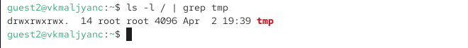

Применение команды ls -l / | grep tmp

## Исследование Sticky-бита

- Повторяю предыдущие шаги. Удалось удалить файл (рис. 34).

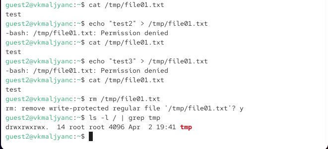

Повторение предыдущих шагов

## Исследование Sticky-бита

- Повышаю свои права до суперпользователя и возвращаю атрибут t на директорию /tmp: su - chmod +t /tmp exit (рис. 35).

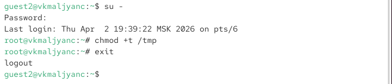

Применение команд su -, chmod +t /tmp, exit

# Выводы

- Я изучила механизмы изменения идентификаторов, применения SetUID- и Sticky-битов. Получила практические навыкы работы в консоли с дополнительными атрибутами. Рассмотрела работу механизма смены идентификатора процессов пользователей, а также влияние бита Sticky на запись и удаление файлов.

# Спасибо за внимание